# Analisando os filmes da atriz Jennifer Lopez

16 de junho de 2017

# Descrevendo as variáveis

Os dados utilizados para essa análise de filmes estão no seguinte endereço: ‘https://www.rottentomatoes.com/celebrity/’. As variáveis usadas foram ‘Rating’ que corresponde a avaliação dos usuários dada em porcentagem e ‘Box Office’ equivalente a bilheteria de cada filme, ou seja, o lucro ou prejuízo para cada filme.

```r
from_page <- read_html("https://www.rottentomatoes.com/celebrity/jennifer_lopez/") %>%
    html_node("#filmographyTbl") %>%
    html_table(fill=TRUE) %>% # Faz parse
    as.tibble()

filmes = from_page %>%
    filter(RATING != "No Score Yet",
           `BOX OFFICE` != "—",
           CREDIT != "Executive Producer") %>%
    mutate(RATING = as.numeric(gsub("%", "", RATING)),
           `BOX OFFICE` = as.numeric(gsub("[$|M]", "", `BOX OFFICE`))) %>%
    filter(`BOX OFFICE` != 'NA')
```

# E o que vamos analisar?

Iremos analisar os tipos de filme da atriz Jennifer Lopez, segundo o sucesso de público (bilheteria) e de crítica (avaliações no rotten tomatoes).

## Agrupamento com duas dimensões

Vamos fazer agrupamento entre a avaliação dos usuários e a bilheteria de cada filme de Jennifer. No gráfico abaixo você pode observar os nomes dos filmes que ela participou, o valor da avaliação e o valor da bilheteria de cada filme.

```r
p = filmes %>%
    ggplot(aes(x = RATING, y = `BOX OFFICE`, label = TITLE)) +
    geom_point(aes(text = paste("Filme:", TITLE, "<br>", "Avaliação:", RATING, "<br>", "Bilheteria:", `BOX OFFICE`)),
             color = "pink")

ggplotly(p, tooltip = "text")
```

```
## We recommend that you use the dev version of ggplot2 with `ggplotly()`
## Install it with: `devtools::install_github('hadley/ggplot2')`
```

[interactive chart not shown]

Na matriz abaixo você pode verificar os possíveis grupos que podem ser feitos entre os filmes:

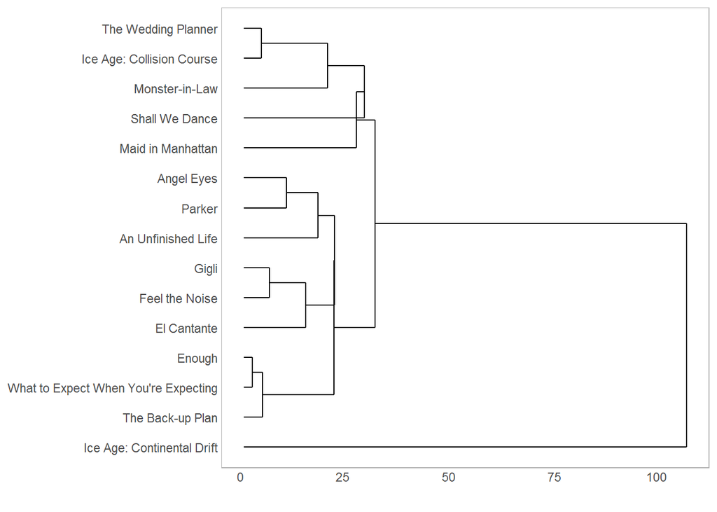

```r
agrupamento_h_2d = filmes %>%
    column_to_rownames("TITLE") %>%
    select(RATING, `BOX OFFICE`) %>%
    dist(method = "euclidean") %>%
    hclust(method = "centroid")

ggdendrogram(agrupamento_h_2d, rotate = TRUE)
```

Como você viu acima foi possível separar os filmes em grupos. Podemos visualizar esses grupos da seguinte forma:

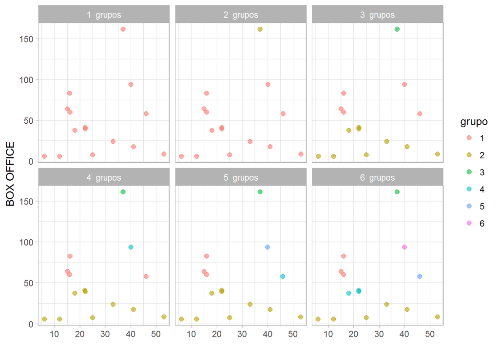

```r
plota_hclusts_2d(agrupamento_h_2d,
                 filmes,
                 c("RATING", "`BOX OFFICE`"),
                 linkage_method = "centroid", ks = 1:6)
```

Como as escalas da bilheteria (Box Office) e da avaliação dos usuários (Rating) são diferentes, a tendência é que os resultados estejam em função da bilheteria já que a distância entre seus valores são maiores. Por isso é preciso padronizar os valores dessas duas variáveis que estamos utilizando, para termos um resultado correto.

## Solução

Como solução é preciso deixar os valores da bilheteria em escala logaritimica para evitar que o resultado esteja em função da bilheteria, como mostrado abaixo:

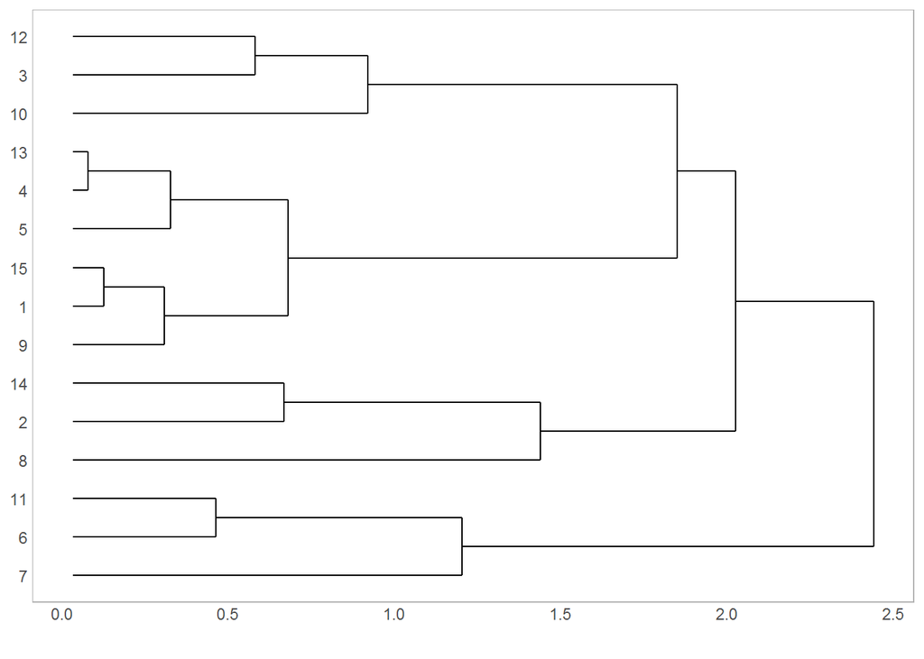

```r
agrupamento_h_2d = filmes %>%
    column_to_rownames("TITLE") %>%
    select(RATING, `BOX OFFICE`) %>%
    mutate(`BOX OFFICE` = log10(`BOX OFFICE`)) %>%
    mutate_all(funs(scale)) %>%
    dist(method = "euclidean") %>%
    hclust(method = "average")

ggdendrogram(agrupamento_h_2d, rotate = TRUE)
```

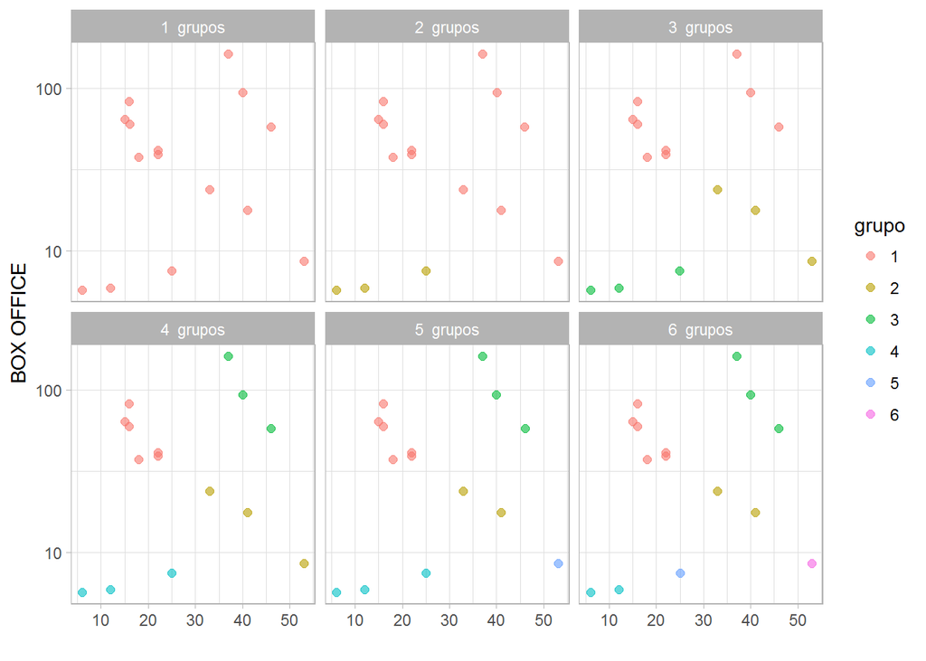

```r
filmes2 = filmes %>% mutate(`BOX OFFICE` = log10(`BOX OFFICE`))

plota_hclusts_2d(agrupamento_h_2d,
                 filmes2,
                 c("RATING", "`BOX OFFICE`"),
                 linkage_method = "ward.D", ks = 1:6) + scale_y_log10()
```

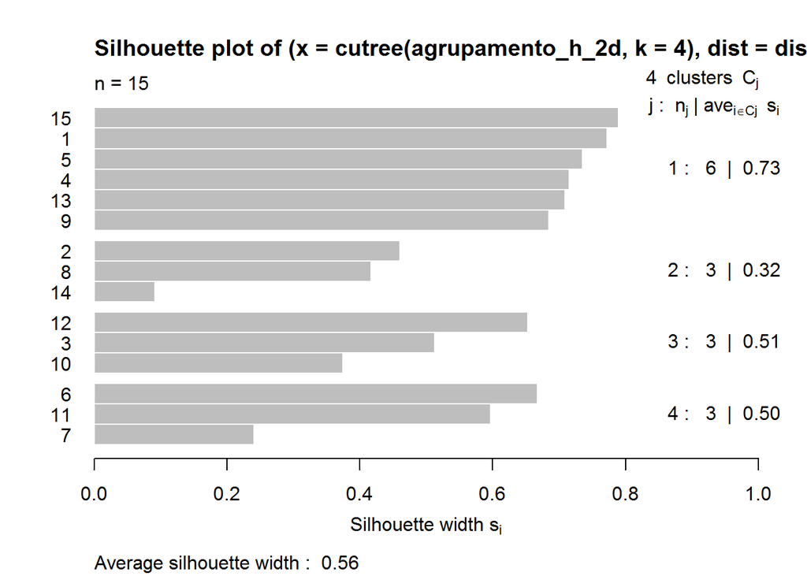

```r
distancias = filmes %>%
    column_to_rownames("TITLE") %>%
    select(RATING, `BOX OFFICE`) %>%
    mutate(`BOX OFFICE` = log10(`BOX OFFICE`)) %>%
    mutate_all(funs(scale)) %>%
    dist(method = "euclidean")

plot(silhouette(cutree(agrupamento_h_2d, k = 4), distancias))
```

A matriz de distância acima nos mostra que todos os filmes estão devidamente nos grupos corretos, ou seja, os filmes em cada grupo parecem ser semelhantes. Vamos agora dar nome a cada grupo.

Como você pode ver no último gráfico que mostra os filmes separados em grupos…escolhi agrupar os filmes em quatro grupos e defini-los da seguinte maneira:

1. **Grupo 1:** ‘Os meio termos’ (na cor rosa): não foram tão bem avaliados, mas o valor da bilheteria corresponde a um dos melhores valores relacionados aos outros grupos. Um exemplo de filme para esse grupo é o chamado ‘Monster-in-Law’ que obteve o terceiro melhor valor de bilheteria, mas teve um valor muito baixo de avaliação.
2. **Grupo 2:** ‘Os queridinhos do público’ (na cor amarela): por conseguirem um boa avaliação, porém não obtiveram tanto sucesso de bilheteria. Tendo como exemplo o filme ‘An Unfinished Life’ que foi o filme que obteve o maior número na avaliação dos usuários, porém o valor da bilheteria está entre os quatro menores valores.
3. **Grupo 3:** ‘Sucesso total’ (na cor verde): por terem ótimos valores tanto na bilheteria quanto na porcentagem de avaliação dos usuários. O filme que pode representar esse grupo é o ‘Maid in Manhattan’ que teve ótimos valores tanto de bilheteria quanto de nota.
4. **Grupo 4:** ‘Os menos favorecidos’ (na cor azul): por terem a característica de insucesso na bilheteria. O filme que representa corretamente esse grupo é o chamado ‘Gigli’ ele obteve a menor porcentagem de nota e o menor valor de bilheterria.